# Uygulama: Çoklu Regresyon Analizi

Finansal Ekonometri (MPİ-TYL)

Prof. Dr. Hüseyin Taştan

Yıldız Teknik Üniversitesi

# 1 R’da çoklu regresyon modelinin tahmini

Popülasyon regresyon modeli aşağıdaki gibi yazılabilir:
$$y = \beta_0 + \beta_1 x_1 + \beta_2 x_2 + \ldots
+ \beta_k x_k + u$$

Bu model R’da `lm()` fonksiyonu ile aşağıdaki syntax kullanılarak tahmin edilebilir:

```r
lm(formula = y ~ x1 + x2 + ... + xk, data, ...)
```

veya

```r
lm(y ~ x1 + x2 + ... + xk, options)
```

Modele sabit terim otomatik olarak eklenir. Eğer modelden sabiti çıkarmak istersek:

```r
lm(y ~ 0 + x1 + x2 + ... + xk, data, ...)
```

The `lm()` command accepts several options regarding the specification. See the help files.

As we’ve already seen many times, if you want the results to be stored and displayed in a table format you can use

```r
res <- lm(y ~ 0 + x1 + x2 + ... + xk, data, ...)
summary(res)
```

## 1.1 Örnek: öğrenci başarısı

```r
library(wooldridge)

GPAres <- lm(colGPA ~ hsGPA + ACT, data = gpa1)

summary(GPAres)
```

```
##
## Call:
## lm(formula = colGPA ~ hsGPA + ACT, data = gpa1)
##
## Residuals:
##      Min       1Q   Median       3Q      Max
## -0.85442 -0.24666 -0.02614  0.28127  0.85357
##
## Coefficients:
##             Estimate Std. Error t value Pr(>|t|)
## (Intercept) 1.286328   0.340822   3.774 0.000238 ***
## hsGPA       0.453456   0.095813   4.733 5.42e-06 ***
## ACT         0.009426   0.010777   0.875 0.383297
## ---
## Signif. codes:  0 '***' 0.001 '**' 0.01 '*' 0.05 '.' 0.1 ' ' 1
##
## Residual standard error: 0.3403 on 138 degrees of freedom
## Multiple R-squared:  0.1764, Adjusted R-squared:  0.1645
## F-statistic: 14.78 on 2 and 138 DF,  p-value: 1.526e-06
```

Örneklem regresyon fonksiyonu (SRF): (standart hatalar parantez içindedir)
$$\widehat{colGPA} = \underset{(0.341)} {1.29} + \underset{(0.096)}
{0.453}~ hsGPA + \underset{(0.011)} {0.0094}~ ACT$$
$n=141$ öğrenci, $colGPA$: üniversite öğrencilerinin başarı notu (GPA, 4 üzerinden puan) , $hsGPA$: lise başarı notu, $ACT$: achievement test score (üniversiteye giriş sınavı sonucu).

## 1.2 Örnek: Ücret denklemi

```r
summary( lm(log(wage) ~ educ+exper+tenure, data=wage1) )
```

```
##
## Call:
## lm(formula = log(wage) ~ educ + exper + tenure, data = wage1)
##
## Residuals:
##      Min       1Q   Median       3Q      Max
## -2.05802 -0.29645 -0.03265  0.28788  1.42809
##
## Coefficients:
##             Estimate Std. Error t value Pr(>|t|)
## (Intercept) 0.284360   0.104190   2.729  0.00656 **
## educ        0.092029   0.007330  12.555  < 2e-16 ***
## exper       0.004121   0.001723   2.391  0.01714 *
## tenure      0.022067   0.003094   7.133 3.29e-12 ***
## ---
## Signif. codes:  0 '***' 0.001 '**' 0.01 '*' 0.05 '.' 0.1 ' ' 1
##
## Residual standard error: 0.4409 on 522 degrees of freedom
## Multiple R-squared:  0.316,  Adjusted R-squared:  0.3121
## F-statistic: 80.39 on 3 and 522 DF,  p-value: < 2.2e-16
```

## 1.3 Örnek: yeni doğan bebeklerin sağlığı

Veri seti: `bwght`, değişken tanımları için bkz. `?bwght`

```r
bebek_agirlik_modeli <- lm(bwght ~  cigs + parity + faminc + motheduc + fatheduc, data=bwght)
summary(bebek_agirlik_modeli)
```

```
##
## Call:
## lm(formula = bwght ~ cigs + parity + faminc + motheduc + fatheduc,
##     data = bwght)
##
## Residuals:
##     Min      1Q  Median      3Q     Max
## -95.796 -11.960   0.643  12.679 150.879
##
## Coefficients:
##              Estimate Std. Error t value Pr(>|t|)
## (Intercept) 114.52433    3.72845  30.716  < 2e-16 ***
## cigs         -0.59594    0.11035  -5.401 8.02e-08 ***
## parity        1.78760    0.65941   2.711  0.00681 **
## faminc        0.05604    0.03656   1.533  0.12559
## motheduc     -0.37045    0.31986  -1.158  0.24702
## fatheduc      0.47239    0.28264   1.671  0.09492 .
## ---
## Signif. codes:  0 '***' 0.001 '**' 0.01 '*' 0.05 '.' 0.1 ' ' 1
##
## Residual standard error: 19.79 on 1185 degrees of freedom
##   (197 observations deleted due to missingness)
## Multiple R-squared:  0.03875,    Adjusted R-squared:  0.03469
## F-statistic: 9.553 on 5 and 1185 DF,  p-value: 5.986e-09
```

Cigs katsayısının yorumu: hamilelik süresince günde içilen ortalama sigara sayısı bir artarsa yeni doğan bebek ağırlıkları ortalama yaklaşık 0.60 birim azalmaktadır (bebek ağırlığı ons cinsinden ölçülmüştür, bir ons = yaklaşık 30 gr.)

# 2 Hipotez testleri

## 2.1 t testi: örnek

```r
library(wooldridge)
wagereg <- lm(log(wage) ~ educ + exper + tenure, data = wage1)
summary(wagereg)
```

```
##
## Call:
## lm(formula = log(wage) ~ educ + exper + tenure, data = wage1)
##
## Residuals:
##      Min       1Q   Median       3Q      Max
## -2.05802 -0.29645 -0.03265  0.28788  1.42809
##
## Coefficients:
##             Estimate Std. Error t value Pr(>|t|)
## (Intercept) 0.284360   0.104190   2.729  0.00656 **
## educ        0.092029   0.007330  12.555  < 2e-16 ***
## exper       0.004121   0.001723   2.391  0.01714 *
## tenure      0.022067   0.003094   7.133 3.29e-12 ***
## ---
## Signif. codes:  0 '***' 0.001 '**' 0.01 '*' 0.05 '.' 0.1 ' ' 1
##
## Residual standard error: 0.4409 on 522 degrees of freedom
## Multiple R-squared:  0.316,  Adjusted R-squared:  0.3121
## F-statistic: 80.39 on 3 and 522 DF,  p-value: < 2.2e-16
```

Tecrübenin popülasyon katsayısının sıfır olduğunu söyleyen hipotezi test ediniz. Karşı hipotez pozitif olduğunu söylesin. Yani,
$$H_0: \beta_2 = 0$$
$$H_1: \beta_2 > 0$$

Regresyon çıktısında t istatistiği hesaplanmıştır, $t_{\hat{\beta}_2}=2.391=0.004/0.0017$.

Kritik değerler: t(522) yaklaşık olarak standart normal dağılıma sahiptir:

```r
# CV for alpha=5% and 1% using the t distribution with 522 d.f.
# Using the quantile function for t (qt)
alpha <- c(0.05, 0.01)
qt(1-alpha, 522)
```

```
## [1] 1.647778 2.333513
```

```r
# Critical values for alpha=5% and 1% using the normal approximation:
# Using the quantile function for normal distribution (qnorm)
qnorm(1-alpha)
```

```
## [1] 1.644854 2.326348
```

t istatistiği %1 düzeyindeki kritik değerden daha büyüktür: $t_{\hat{\beta}_2}=2.391>2.33$. Öyleyse %1 düzeyinde boş hipotez reddedilir.

R ile p-değerini bulalım:

```r
pt(2.391,522, lower.tail = FALSE)
```

```
## [1] 0.008577905
```

```r
# or
1-pt(2.391,522)
```

```
## [1] 0.008577905
```

P-değeri<0.01 olduğu için boş hipotez %1 düzeyinde reddedilir.

## 2.2 t testi: Campus Crime Model

```r
( crimeres <- summary( lm(log(crime) ~ log(enroll), data=campus) ) )
```

```
##
## Call:
## lm(formula = log(crime) ~ log(enroll), data = campus)
##
## Residuals:
##     Min      1Q  Median      3Q     Max
## -4.5136 -0.3858  0.1174  0.4363  2.5782
##
## Coefficients:
##             Estimate Std. Error t value Pr(>|t|)
## (Intercept)  -6.6314     1.0335  -6.416 5.44e-09 ***
## log(enroll)   1.2698     0.1098  11.567  < 2e-16 ***
## ---
## Signif. codes:  0 '***' 0.001 '**' 0.01 '*' 0.05 '.' 0.1 ' ' 1
##
## Residual standard error: 0.8946 on 95 degrees of freedom
## Multiple R-squared:  0.5848, Adjusted R-squared:  0.5804
## F-statistic: 133.8 on 1 and 95 DF,  p-value: < 2.2e-16
```

Suçun okul büyüklüğüne göre esnekliğinin bir olduğunu test ediniz:
$$H_0: \beta_1 = 1$$
Alternatif hipotez:
$$H_1: \beta_1>1$$
T testi:
$$t =\frac{tahmin-hipotez}{standart~
hata}= \frac{1.2698-1}{0.1098}=2.46\sim t(95)$$
% 1 düzeyindeki kritik değer:

```r
qt(0.99, 95)
```

```
## [1] 2.366243
```

Hesaplanan t kritik değerden büyüktür, öyleyse boş hipotez red.

P değerini bulalım:

```r
pt(2.46, 95, lower.tail = FALSE)
```

```
## [1] 0.007850607
```

P değeri 0.01 değerinden küçüktür. Öyleyse % 1 anlamlılık düzeyinde boş hipotez red. Esneklik 1’en büyüktür.

## 2.3 t testi: House prices

```r
houseres <- lm(log(price) ~ log(nox)+log(dist)+rooms+stratio, data=hprice2)
summary(houseres)
```

```
##
## Call:
## lm(formula = log(price) ~ log(nox) + log(dist) + rooms + stratio,
##     data = hprice2)
##
## Residuals:
##      Min       1Q   Median       3Q      Max
## -1.05890 -0.12427  0.02128  0.12882  1.32531
##
## Coefficients:
##              Estimate Std. Error t value Pr(>|t|)
## (Intercept) 11.083861   0.318111  34.843  < 2e-16 ***
## log(nox)    -0.953539   0.116742  -8.168 2.57e-15 ***
## log(dist)   -0.134339   0.043103  -3.117  0.00193 **
## rooms        0.254527   0.018530  13.736  < 2e-16 ***
## stratio     -0.052451   0.005897  -8.894  < 2e-16 ***
## ---
## Signif. codes:  0 '***' 0.001 '**' 0.01 '*' 0.05 '.' 0.1 ' ' 1
##
## Residual standard error: 0.265 on 501 degrees of freedom
## Multiple R-squared:  0.584,  Adjusted R-squared:  0.5807
## F-statistic: 175.9 on 4 and 501 DF,  p-value: < 2.2e-16
```

**Alıştırma**: log(nox) katsayısının -1 olduğunu söyleyen hipotezi iki taraflı alternatifle sınayınız.

# 3 F test

## 3.1 Regresyonun bir bütün olarak istatistiksel anlamlılığı

Ev fiyatları modeli:

```r
houseres <- lm(log(price) ~ log(nox)+log(dist)+rooms+stratio, data=hprice2)
summary(houseres)
```

```
##
## Call:
## lm(formula = log(price) ~ log(nox) + log(dist) + rooms + stratio,
##     data = hprice2)
##
## Residuals:
##      Min       1Q   Median       3Q      Max
## -1.05890 -0.12427  0.02128  0.12882  1.32531
##
## Coefficients:
##              Estimate Std. Error t value Pr(>|t|)
## (Intercept) 11.083861   0.318111  34.843  < 2e-16 ***
## log(nox)    -0.953539   0.116742  -8.168 2.57e-15 ***
## log(dist)   -0.134339   0.043103  -3.117  0.00193 **
## rooms        0.254527   0.018530  13.736  < 2e-16 ***
## stratio     -0.052451   0.005897  -8.894  < 2e-16 ***
## ---
## Signif. codes:  0 '***' 0.001 '**' 0.01 '*' 0.05 '.' 0.1 ' ' 1
##
## Residual standard error: 0.265 on 501 degrees of freedom
## Multiple R-squared:  0.584,  Adjusted R-squared:  0.5807
## F-statistic: 175.9 on 4 and 501 DF,  p-value: < 2.2e-16
```

Modelin bir bütün olarak anlamlı olup olmadığına ilişkin F test istatistiği regresyon çıktısında verilmiştir:
$$F = 175.9\sim F(4, 501)$$
Buna ilişkin p değeri oldukça küçüktür (p-value: < 2.2e-16). Öyleyse model bir bütün olarak istatistiksel bakımdan anlamlıdır.

## 3.2 Dışlama kısıtları: örnek

Yeni doğan bebeklerin ağırlıklarında anne ve babanın eğitim düzeyinin birlikte anlamlı olup olmadığını test etmek istiyoruz. Önce kayıp gözlemleri silelim:

```r
data(bwght, package='wooldridge')
# omit missing observations (many missing values in fatheduc)
bwght <- na.omit(bwght)
```

Kısıtlanmamış model:

```r
unrest.bwght <- lm(bwght ~  cigs + parity + faminc + motheduc + fatheduc, data=bwght)
summary(unrest.bwght)
```

```
##
## Call:
## lm(formula = bwght ~ cigs + parity + faminc + motheduc + fatheduc,
##     data = bwght)
##
## Residuals:
##     Min      1Q  Median      3Q     Max
## -95.796 -11.960   0.643  12.679 150.879
##
## Coefficients:
##              Estimate Std. Error t value Pr(>|t|)
## (Intercept) 114.52433    3.72845  30.716  < 2e-16 ***
## cigs         -0.59594    0.11035  -5.401 8.02e-08 ***
## parity        1.78760    0.65941   2.711  0.00681 **
## faminc        0.05604    0.03656   1.533  0.12559
## motheduc     -0.37045    0.31986  -1.158  0.24702
## fatheduc      0.47239    0.28264   1.671  0.09492 .
## ---
## Signif. codes:  0 '***' 0.001 '**' 0.01 '*' 0.05 '.' 0.1 ' ' 1
##
## Residual standard error: 19.79 on 1185 degrees of freedom
## Multiple R-squared:  0.03875,    Adjusted R-squared:  0.03469
## F-statistic: 9.553 on 5 and 1185 DF,  p-value: 5.986e-09
```

Kısıtlanmış model (motheduc ve fatheduc dışlandı)

```r
rest.bwght <- lm(bwght ~  cigs + parity + faminc, data=bwght)
summary(rest.bwght)
```

```
##
## Call:
## lm(formula = bwght ~ cigs + parity + faminc, data = bwght)
##
## Residuals:
##     Min      1Q  Median      3Q     Max
## -95.811 -11.552   0.524  12.739 150.848
##
## Coefficients:
##              Estimate Std. Error t value Pr(>|t|)
## (Intercept) 115.46993    1.65590  69.733  < 2e-16 ***
## cigs         -0.59785    0.10877  -5.496 4.74e-08 ***
## parity        1.83227    0.65754   2.787  0.00541 **
## faminc        0.06706    0.03239   2.070  0.03865 *
## ---
## Signif. codes:  0 '***' 0.001 '**' 0.01 '*' 0.05 '.' 0.1 ' ' 1
##
## Residual standard error: 19.8 on 1187 degrees of freedom
## Multiple R-squared:  0.03642,    Adjusted R-squared:  0.03398
## F-statistic: 14.95 on 3 and 1187 DF,  p-value: 1.472e-09
```

F test istatistiğini açıkça hesaplayalım:

```r
n <- length(unrest.bwght$residuals)
k.unrest <- length(unrest.bwght$coefficients)-1
k.rest <- length(rest.bwght$coefficients)-1
q <- k.unrest - k.rest
q
```

[1] 2

```r
USSR <- sum(unrest.bwght$residuals^2)
RSSR <- sum(rest.bwght$residuals^2)
F <- ((RSSR-USSR)/USSR) * (n - k.unrest - 1)/q
F
```

[1] 1.437269

Bağımlı değişken hem kısıtlanmamış hem de kısıtlanmış modelde aynı ise $R^2$ versiyonu da kullanılabilir:

```r
# Unrestricted model's Rsquared
URsq <- summary(unrest.bwght)$r.squared
# Restricted model's Rsquared
RRsq <- summary(rest.bwght)$r.squared
# Compute the F statistic
F <- ((URsq-RRsq)/(1-URsq)) * (n - k.unrest - 1)/q
F
```

[1] 1.437269

Karar kuralı: hesaplanan F test değeri F(q,n-k-1) kritik değerinden büyükse (verilmiş bir alpha düzeyinde) boş hipotez red.

%5 düzeyinde kritik değer:

```r
alpha <- 0.05
Fcv05 <- qf(alpha, q, n-k.unrest-1, lower.tail = FALSE)
Fcv05
```

[1] 3.003318

Veya:

```r
qf(1-alpha, q, n-k.unrest-1, lower.tail = TRUE)
```

[1] 3.003318

$\alpha = 0.1$ düzeyinde kritik değer:

```r
qf(0.9, q, n-k.unrest-1)
```

[1] 2.307065

Hesaplanan F istatistiği %10 düzeyindeki kritik değerden küçük olduğu için boş hipotez reddedilemez. motheduc ve fatheduc değişkenleri birlikte istatistik bakımından anlamsızdır.

P değerinin hesaplanması:

```r
# p-value
1-pf(F,q,n-k.unrest-1)
```

[1] 0.2379896

p-değeri=0.238>0.1 olduğu için $H_0$ reddedilmez.

### 3.2.1 `linearHypothesis()` fonksiyonu ile F testi

`linearHypothesis()` fonksiyonu `{car}` paketinin bir parçasıdır. Önceki örneğimiz için F istatistiğinin doğrudan hesaplanması:

```r
# install.packages("car")
library(car)
linearHypothesis(unrest.bwght, c("motheduc=0","fatheduc=0"))
```

```
## Linear hypothesis test
##
## Hypothesis:
## motheduc = 0
## fatheduc = 0
##
## Model 1: restricted model
## Model 2: bwght ~ cigs + parity + faminc + motheduc + fatheduc
##
##   Res.Df    RSS Df Sum of Sq      F Pr(>F)
## 1   1187 465167
## 2   1185 464041  2    1125.7 1.4373  0.238
```

## 3.3 Doğrusal kısıtlar: Ev değerlemeleri

Kısıtlanmamış model:

```r
data(hprice1, package='wooldridge')
# unrestricted regression
unrest <- lm(lprice ~  lassess + llotsize + lsqrft + bdrms, data=hprice1)
summary(unrest)
anova(unrest)
```

```
##
## Call:
## lm(formula = lprice ~ lassess + llotsize + lsqrft + bdrms, data = hprice1)
##
## Residuals:
##      Min       1Q   Median       3Q      Max
## -0.53337 -0.06333  0.00686  0.07836  0.60825
##
## Coefficients:
##              Estimate Std. Error t value Pr(>|t|)
## (Intercept)  0.263743   0.569665   0.463    0.645
## lassess      1.043065   0.151446   6.887 1.01e-09 ***
## llotsize     0.007438   0.038561   0.193    0.848
## lsqrft      -0.103238   0.138430  -0.746    0.458
## bdrms        0.033839   0.022098   1.531    0.129
## ---
## Signif. codes:  0 '***' 0.001 '**' 0.01 '*' 0.05 '.' 0.1 ' ' 1
##
## Residual standard error: 0.1481 on 83 degrees of freedom
## Multiple R-squared:  0.7728, Adjusted R-squared:  0.7619
## F-statistic: 70.58 on 4 and 83 DF,  p-value: < 2.2e-16
##
## Analysis of Variance Table
##
## Response: lprice
##           Df Sum Sq Mean Sq  F value Pr(>F)
## lassess    1 6.1385  6.1385 279.7090 <2e-16 ***
## llotsize   1 0.0030  0.0030   0.1378 0.7114
## lsqrft     1 0.0031  0.0031   0.1394 0.7098
## bdrms      1 0.0515  0.0515   2.3449 0.1295
## Residuals 83 1.8215  0.0219
## ---
## Signif. codes:  0 '***' 0.001 '**' 0.01 '*' 0.05 '.' 0.1 ' ' 1
```

lprice=log ev fiyatları, lassess=log ekspertiz değeri, ve eve ilişkin diğer değişkenler.

Kısıtlanmamış modelin SSR değerini saklayalım:

```r
SSRu <- sum(unrest$residuals^2)
SSRu
```

```
## [1] 1.821529
```

Kısıtlanmış (Restricted) model:

```r
# restricted regression
# define the new dependent variable
pricedif <- hprice1$lprice - hprice1$lassess
rest <- lm(pricedif ~  1, data=hprice1)
anova(rest)
# Restricted SSR
SSRr <- sum(resid(rest)^2)
SSRr
```

```
## Analysis of Variance Table
##
## Response: pricedif
##           Df Sum Sq  Mean Sq F value Pr(>F)
## Residuals 87 1.8801 0.021611
## [1] 1.880149
```

F istatistiği:

```r
n <- nobs(unrest)
k <- length(unrest$coefficients)-1
q <- 4
F <- ((SSRr-SSRu)/SSRu) * (n-k-1)/q
F
```

[1] 0.6677722

Karar kuralı için kritik değer:

```r
alpha <- 0.05
Fcv05 <- qf(alpha, q, n-k-1, lower.tail = FALSE)
Fcv05
```

[1] 2.481661

or

```r
qf(1-alpha, q, n-k-1, lower.tail = TRUE)
```

[1] 2.481661

P değeri:

```r
1-pf(F,q,n-k-1)
```

[1] 0.6161596

P değeri makül alpha değerlerinden daha büyüktür. Öyleyse boş hipotez kabul edilir. Ev değerlemeleri rasyoneldir.

`linearHypothesis()` ile otomatik hesaplama:

```r
linearHypothesis(unrest, c("lassess=1","llotsize=0","lsqrft=0","bdrms=0"))
```

```
## Linear hypothesis test
##
## Hypothesis:
## lassess = 1
## llotsize = 0
## lsqrft = 0
## bdrms = 0
##
## Model 1: restricted model
## Model 2: lprice ~ lassess + llotsize + lsqrft + bdrms
##
##   Res.Df    RSS Df Sum of Sq      F Pr(>F)
## 1     87 1.8801
## 2     83 1.8215  4   0.05862 0.6678 0.6162
```

# 4 Kategorik değişkenler

Ücret denklemi

```r
wagereg1 <- lm(log(wage) ~ female + educ, data=wage1)
summary(wagereg1)
```

```
##
## Call:
## lm(formula = log(wage) ~ female + educ, data = wage1)
##
## Residuals:
##      Min       1Q   Median       3Q      Max
## -2.02672 -0.27470 -0.03731  0.26219  1.34738
##
## Coefficients:
##              Estimate Std. Error t value Pr(>|t|)
## (Intercept)  0.826269   0.094054   8.785   <2e-16 ***
## female      -0.360865   0.039024  -9.247   <2e-16 ***
## educ         0.077203   0.007047  10.955   <2e-16 ***
## ---
## Signif. codes:  0 '***' 0.001 '**' 0.01 '*' 0.05 '.' 0.1 ' ' 1
##
## Residual standard error: 0.4455 on 523 degrees of freedom
## Multiple R-squared:  0.3002, Adjusted R-squared:  0.2975
## F-statistic: 112.2 on 2 and 523 DF,  p-value: < 2.2e-16
```

Başka nicel değişkenler ekleyelim:

```r
wagereg2 <- lm(log(wage) ~ female + educ + exper + tenure, data=wage1)
summary(wagereg2)
```

```
##
## Call:
## lm(formula = log(wage) ~ female + educ + exper + tenure, data = wage1)
##
## Residuals:
##      Min       1Q   Median       3Q      Max
## -1.91588 -0.26192 -0.02399  0.26349  1.27352
##
## Coefficients:
##              Estimate Std. Error t value Pr(>|t|)
## (Intercept)  0.501348   0.101902   4.920 1.16e-06 ***
## female      -0.301146   0.037246  -8.085 4.37e-15 ***
## educ         0.087462   0.006939  12.605  < 2e-16 ***
## exper        0.004629   0.001627   2.845  0.00461 **
## tenure       0.017367   0.002976   5.835 9.45e-09 ***
## ---
## Signif. codes:  0 '***' 0.001 '**' 0.01 '*' 0.05 '.' 0.1 ' ' 1
##
## Residual standard error: 0.416 on 521 degrees of freedom
## Multiple R-squared:  0.3923, Adjusted R-squared:  0.3876
## F-statistic: 84.07 on 4 and 521 DF,  p-value: < 2.2e-16
```

Female kukla katsayısı negatif ve anlamlı. Educ, exper, tenure değişkenlerini dikkate aldıktan sonra da kadınlar ortalamada erkeklerden daha az kazanıyor.

# 5 Karesel Model

## 5.1 Örnek: ücret denklemi

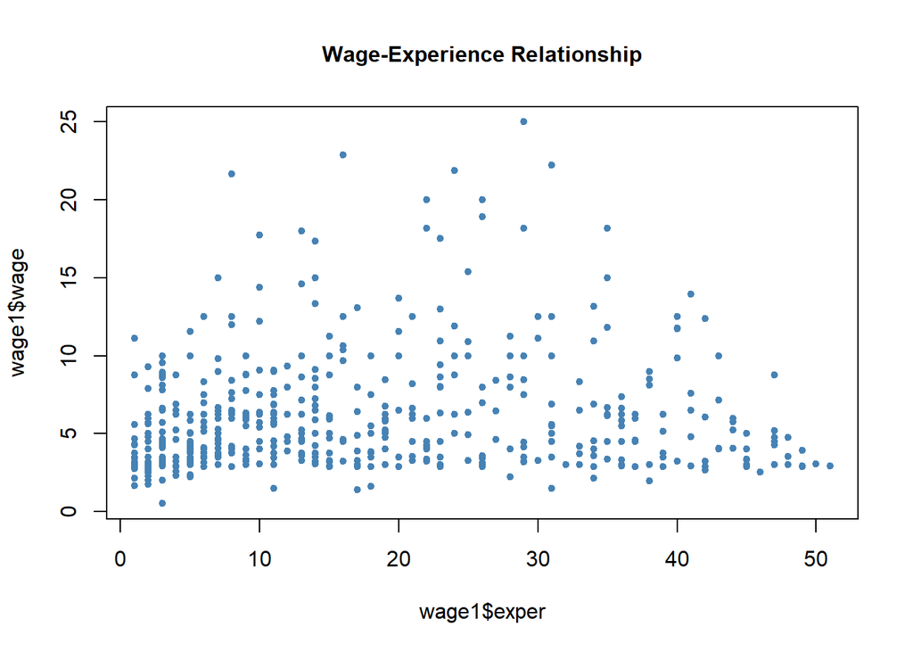

```r
# scatter plot
plot(wage1$exper, wage1$wage,
     col = "steelblue",
     pch = 20,
     main = "Wage-Experience Relationship",
     cex.main = 1)
```

[figure not shown]

```r
# scatter plot with quadratic fit
# requires ggplot2
library(ggplot2)
ggplot(wage1, aes(x=exper, y=wage)) + geom_point()+stat_smooth(se=F,method='lm', formula=y~poly(x,2))
```

```r
# OLS fit
reswage <- lm(log(wage)~educ+exper+I(exper^2),data=wage1)
summary(reswage)
```

```
##
## Call:
## lm(formula = log(wage) ~ educ + exper + I(exper^2), data = wage1)
##
## Residuals:
##      Min       1Q   Median       3Q      Max
## -1.96387 -0.29375 -0.04009  0.29497  1.30216
##
## Coefficients:
##               Estimate Std. Error t value Pr(>|t|)
## (Intercept)  0.1279975  0.1059323   1.208    0.227
## educ         0.0903658  0.0074680  12.100  < 2e-16 ***
## exper        0.0410089  0.0051965   7.892 1.77e-14 ***
## I(exper^2)  -0.0007136  0.0001158  -6.164 1.42e-09 ***
## ---
## Signif. codes:  0 '***' 0.001 '**' 0.01 '*' 0.05 '.' 0.1 ' ' 1
##
## Residual standard error: 0.4459 on 522 degrees of freedom
## Multiple R-squared:  0.3003, Adjusted R-squared:  0.2963
## F-statistic: 74.67 on 3 and 522 DF,  p-value: < 2.2e-16
```

Dönüm noktası:
$$exper^* =
\frac{0.041}{0.00142}=28.87$$

yaklışık 29 yıldır.

# 6 Uygulama: Finansal varlık fiyatlama modeli

Finansal varlık fiyatlama modeli (capital assets pricing model, CAPM) bir hisse senedinin beklenen getirisini piyasa riski ile ilişkilendirir.

$$(R^A_t - R^f_t) = \beta_0 + \beta_1
(R^M_t - R^f_t) + u_t$$
Burada $R^A_t$ A hisse senedinin $t$ zamanındaki (örneğin ay) getirisi, $R^M_t$ piyasa portföyü M için getiri oranı (endeks getiri oranı kullanılabilir, örneğin S&P-500 getirileri) ve $R^f_t$ risksiz getiri oranıdır (devlet tahvillerinin faiz oranı kullanılabilir).

Bu modelde $\beta_1$ finansal varlığın risk düzeyi hakkında bilgi içerir. $\beta_1=1$ ise orta düzey risk (piyasa portföy riski düzeyinde), $\beta_1>1$ yüksek sistematik risk ve beklenen getiri yüksek, $\beta_1<1$ düşük sistematik risk ve beklenen getiri düşük.

Örnek:

```r
# CAPM application (data from Brooks text)

library(tidyverse)
library(lubridate)
library(readxl)
capm <- read_excel("Data/capm.xls")
# yeni date değişkeni
capm <- capm %>%
  mutate(date = lubridate::ymd(Date),
         month = lubridate::month(date))
```

```r
# getiri oranlarını hesapla
capm <- capm %>%
  mutate(r_SANDP = 100*(log(SANDP)-lag(log(SANDP), order_by = date)),
         r_FORD = 100*(log(FORD)-lag(log(FORD), order_by = date)),
         r_GE = 100*(log(GE)-lag(log(GE), order_by = date)),
         r_MICROSOFT = 100*(log(MICROSOFT)-lag(log(MICROSOFT), order_by = date)),
         r_ORACLE = 100*(log(ORACLE)-lag(log(ORACLE), order_by = date))
  )
```

```r
# fazla getiri (excess return)
capm <- capm %>%
  mutate(er_SANDP = r_SANDP - USTB3M/12,
         er_FORD = r_FORD - USTB3M/12,
         er_GE = r_GE - USTB3M/12,
         er_MICROSOFT = r_MICROSOFT - USTB3M/12,
         er_ORACLE = r_ORACLE - USTB3M/12
         )
```

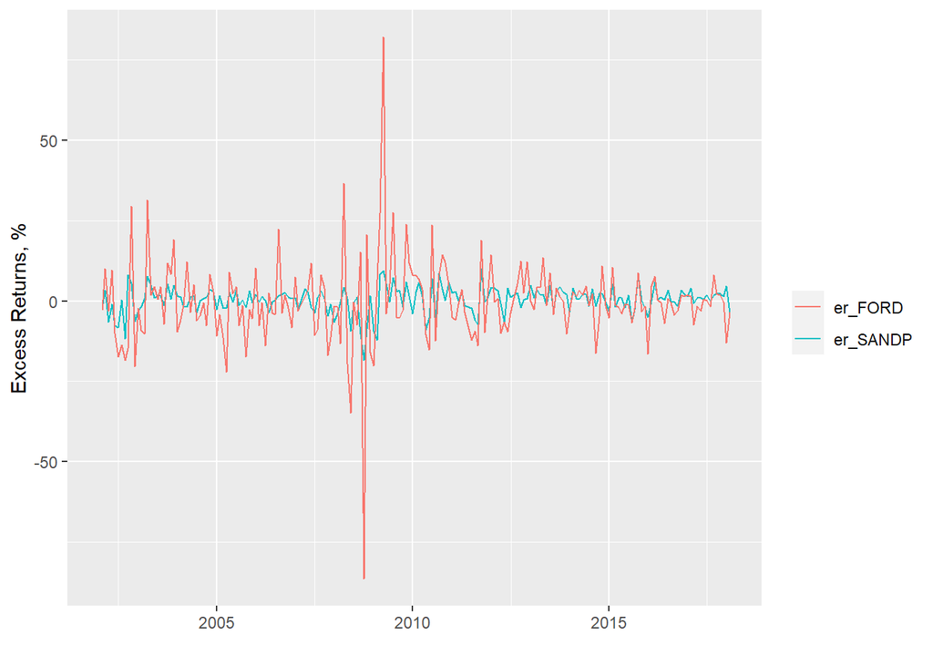

```r
# ts plot SP-500 ve FORD excess returns
capm %>%
  ggplot() +
  geom_line(aes(date, er_SANDP, color = "er_SANDP")) +
  geom_line(aes(date, er_FORD, color = "er_FORD"))+
  labs(color="",
       x = "",
       y = "Excess Returns, %")
```

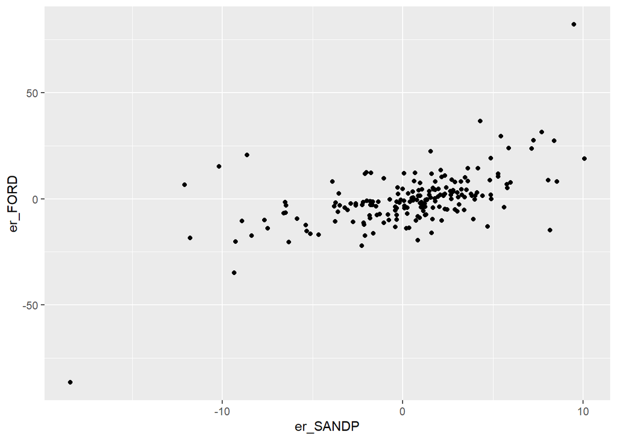

```r
# scatter plot
capm %>%
  ggplot(aes(er_SANDP, er_FORD)) +
  geom_point()
```

```r
# regresyon
capm_reg1 <- lm(er_FORD ~ er_SANDP, data = capm)
summary(capm_reg1)
```

```
##
## Call:
## lm(formula = er_FORD ~ er_SANDP, data = capm)
##
## Residuals:
##     Min      1Q  Median      3Q     Max
## -50.727  -5.027  -1.080   3.482  65.145
##
## Coefficients:
##             Estimate Std. Error t value Pr(>|t|)
## (Intercept)  -0.9560     0.7931  -1.205     0.23
## er_SANDP      1.8898     0.1916   9.862   <2e-16 ***
## ---
## Signif. codes:  0 '***' 0.001 '**' 0.01 '*' 0.05 '.' 0.1 ' ' 1
##
## Residual standard error: 10.98 on 191 degrees of freedom
##   (1 observation deleted due to missingness)
## Multiple R-squared:  0.3374, Adjusted R-squared:  0.3339
## F-statistic: 97.26 on 1 and 191 DF,  p-value: < 2.2e-16
```

Beta katsayısı 1.89 olarak tahmin edildi (istatistik bakımından anlamlı).

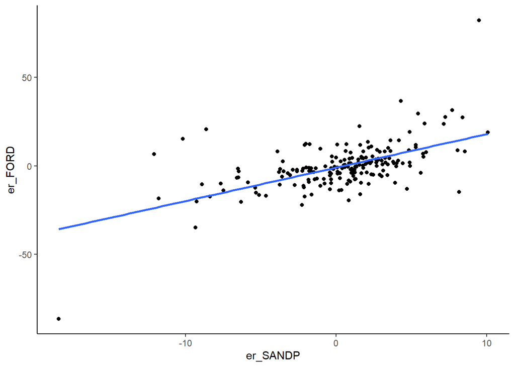

```r
# scatter plot + regression line
capm %>% drop_na() %>%
  ggplot(aes(er_SANDP, er_FORD)) +
  geom_point() +
  geom_smooth(method = "lm", se = FALSE) +
  theme_classic()
```

**Alıştırma**: Bu modelde $H_0: \beta_1 = 1$ hipotezini test ediniz.

# 7 Uygulama: Arbitraj fiyatlama modeli (APT)

APT = Arbitrage-pricing theory

CAPM finansal varlık getirisini piyasa portföy getirisi ile ilişkilendirir. APT ise finansal varlık getirisini sadece piyasa getirisi ile değil diğer tüm makroekonomik veya finansal değişkenlerle (risk kaynaklarıyla) ilişkilendirir. Bu değişkenler arasında enflasyon, sanayi üretimi, faiz oranları ve döviz kurlarındaki değişimler, vs. yer alabilir. Hisse senedi getirileri bu makro değişkenlerdeki beklenmeyen değişimlerle ilişkili olabilir.

```r
# APT application (data from Brooks text)

library(tidyverse)
library(lubridate)
library(readxl)
macro <- read_excel("Data/macro.xls")

macro <- macro %>%
  mutate(date = lubridate::ymd(Date),
         month = lubridate::month(date))
# Değişken tanımları:
# BMINUSA: credit spread (difference in annualised average
# yields between a portfolio of bonds rated AAA and a portfolio of bonds rated
# BAA.)
# CCREDIT: consumer credit
# INDPRO: industrial production index
# M1SUPPLY: M1 money supply
# CPI: consumer price index
# USTB10Y: 10 yıllık hazine bonosu faizi
# USTB3M: 3 aylık hazine bonosu faizi
# SANDP: S&P500 index
# MICROSOFT: hisse senedi fiyatı
```

```r
# değişkenleri değişimler ya da büyüme oranlarına
# dönüştürelim:
# Not: yatırımcılar naif beklentilere sahipse bir değişkendeki dönemden döneme
# değişim beklenmeyen bir değişim ya da sürpriz olarak yorumlanabilir
macro <- macro %>%
  mutate(dspread = BMINUSA - lag(BMINUSA, order_by = date),
         dcredit = CCREDIT - lag(CCREDIT, order_by = date),
         dprod = INDPRO - lag(INDPRO, order_by = date),
         dmoney = M1SUPPLY - lag(M1SUPPLY, order_by = date),
         inflation = 100*(log(CPI) - lag(log(CPI), order_by = date)),
         rterm = c(NA, diff(USTB10Y - USTB3M)),
         dinflation = (inflation - lag(inflation)),
         # SP500 returns
         rsandp = 100*(log(SANDP)-lag(log(SANDP), order_by = date)),
         # excess returns:
         er_msoft = 100*(log(MICROSOFT)-lag(log(MICROSOFT))) - USTB3M/12,
         er_sandp = rsandp - USTB3M/12
         )
```

```r
# Microsoft getiri fazlasının S&P500 ve makro değişkenler üzerine regresyonu
apt_reg1 = lm(er_msoft ~ er_sandp + dprod + dcredit +
                dinflation + dmoney + dspread + rterm, data = macro)
summary(apt_reg1)
```

```
##
## Call:
## lm(formula = er_msoft ~ er_sandp + dprod + dcredit + dinflation +
##     dmoney + dspread + rterm, data = macro)
##
## Residuals:
##     Min      1Q  Median      3Q     Max
## -36.075  -4.440  -0.403   4.616  24.480
##
## Coefficients:
##              Estimate Std. Error t value Pr(>|t|)
## (Intercept)  1.326002   0.475481   2.789  0.00556 **
## er_sandp     1.280799   0.094354  13.574  < 2e-16 ***
## dprod       -0.303032   0.736881  -0.411  0.68113
## dcredit     -0.025364   0.027149  -0.934  0.35078
## dinflation   2.194670   1.264299   1.736  0.08341 .
## dmoney      -0.006871   0.015568  -0.441  0.65919
## dspread      2.260064   4.140284   0.546  0.58548
## rterm        4.733069   1.715814   2.758  0.00609 **
## ---
## Signif. codes:  0 '***' 0.001 '**' 0.01 '*' 0.05 '.' 0.1 ' ' 1
##
## Residual standard error: 7.845 on 375 degrees of freedom
##   (2 observations deleted due to missingness)
## Multiple R-squared:  0.3452, Adjusted R-squared:  0.333
## F-statistic: 28.24 on 7 and 375 DF,  p-value: < 2.2e-16
```

Hangi değişkenler istatistik bakımından anlamlıdır? Hangileri anlamsızdır? Modelin bir bütün olarak anlamlı olduğu söylenebilir mi?

Dışlama kısıtının testi:

```r
library(car)
linearHypothesis(apt_reg1, c("dprod=0","dcredit=0","dmoney=0","dspread=0"))
```

```
## Linear hypothesis test
##
## Hypothesis:
## dprod = 0
## dcredit = 0
## dmoney = 0
## dspread = 0
##
## Model 1: restricted model
## Model 2: er_msoft ~ er_sandp + dprod + dcredit + dinflation + dmoney +
##     dspread + rterm
##
##   Res.Df   RSS Df Sum of Sq      F Pr(>F)
## 1    379 23180
## 2    375 23078  4    101.88 0.4139 0.7986
```

$$F = 0.4139\sim F(4,375)$$
p-değeri = 0.7986, H0 kabul edilir. dprod, dcredit, dmoney ve dspread değişkenleri birlikte anlamsızdır.

Final model:

```r
apt_reg2 = lm(er_msoft ~ er_sandp + dinflation + rterm, data = macro)
summary(apt_reg2)
```

```
##
## Call:
## lm(formula = er_msoft ~ er_sandp + dinflation + rterm, data = macro)
##
## Residuals:
##     Min      1Q  Median      3Q     Max
## -36.260  -4.330  -0.217   4.496  24.781
##
## Coefficients:
##             Estimate Std. Error t value Pr(>|t|)
## (Intercept)   1.0209     0.4010   2.546  0.01129 *
## er_sandp      1.2663     0.0921  13.750  < 2e-16 ***
## dinflation    2.1874     1.2082   1.810  0.07101 .
## rterm         4.7388     1.7087   2.773  0.00582 **
## ---
## Signif. codes:  0 '***' 0.001 '**' 0.01 '*' 0.05 '.' 0.1 ' ' 1
##
## Residual standard error: 7.821 on 379 degrees of freedom
##   (2 observations deleted due to missingness)
## Multiple R-squared:  0.3423, Adjusted R-squared:  0.3371
## F-statistic: 65.75 on 3 and 379 DF,  p-value: < 2.2e-16
```